# Indicadores de Sustentabilidade - TI Verde

Gustavo Moreira** | 11 de junho de 2019

Para promover um ambiente mais sustentável e econômico na Câmara dos Deputados, a equipe do EcoCâmara iniciou um grande projeto visando implementar políticas de sustentabilidade em 14 áreas de atuação, tais como Água, Energia e Materiais descartáveis.

Uma das áreas de atuação é a **TI Verde**, que objetiva reduzir o comsumo de papel de impressão. Para promover a sustentabilidade nessa área e monitorar KPIs relacionados à impressão, a equipe do EcoCâmara, em conjunto com a Primeira Secretaria, solicitou o apoio de nós da DITEC.

Equipes envolvidas neste projeto:

- DITEC/COGES
  - Definição do layout de uma interface web interativa;
  - Extração de dados de planilhas, imagens e databases;
  - Cálculo dos indicadores definidos pela equipe do EcoCâmara;
  - Apuração das economias obtidas no ano de 2018 relativo a 2017.
- CAINF/LOGFI
  - Disponibilização de todos os dados contratuais de impressoras de Janeiro/2017 em diante;
  - Validação das informações apuradas pela COGES.
- SOTIC/SECID
  - Disponibilização do Data Warehouse com dados dos servidores e lotações da Câmara;
  - Disponibilização do portal ‘Inteligência de Negócios’ para hospedagem da aplicação.
- SOTIC/SEDAS
  - Disponibilização dos dados contratuais relativos aos colaboradores terceirizados.
- SOTIC/SEPOR
  - Disponibilização das lotações dos terceirizados cadastrados no CamaraNET.

# 1. Indicadores

Os indicadores mensurados neste projeto foram definidos pela equipe do EcoCâmara e implementados pela COGES conforme descrição abaixo:

## Páginas impressas

Quantidade de páginas impressas, incluindo as provenientes de cópias de documentos.

Objetivo: **Reduzir** a quantidade de impressões da Câmara dos Deputados.

Restrições: Não serão contabilizados neste indicador:

1. Impressões realizadas pela gráfica do DEAPA.

Fontes:

- LOGFI
  - Logs com dados de impressoras e impressões fornecidos mensalmente pelas empresas contratadas

## Impressoras ativas

Quantidade de impressoras das Unidades Administrativas.

Objetivo: **Reduzir** o número total de impressoras das Unidades Administrativas.

Restrições: Não serão contabilizados neste indicador:

1. Impressoras de gabinetes parlamentares;
2. Impressoras do DEMED;
3. Impressoras gráficas do DEAPA.

Fontes:

- LOGFI
  - Logs com dados de impressoras e impressões fornecidos mensalmente pelas empresas contratadas.

## Impressoras por usuário

Quantidade de usuários por impressoras nas Unidades Gestoras de Impressão.

Objetivo: **Aumentar** a proporção de usuários por impressora **reduzindo** o número total de impressoras.

Restrições: Não serão contabilizados neste indicador:

1. Impressoras e usuários associados a gabinetes parlamentares;
2. Impressoras e usuários associados ao DEMED;
3. Impressoras e usuários associados à gráfica do DEAPA;
4. Servidores aposentados.

Fontes:

- LOGFI
  - Logs com dados de impressoras e impressões fornecidos mensalmente pelas empresas contratadas
- SECID
  - Dados de lotações e servidores da Câmara
- SEDAS
  - Dados dos funcionários terceirizados
- SEPOR
  - Lotação atribuída aos terceirizados no CamaraNET

## Impressões por usuário

Quantidade de páginas impressas por usuário, incluindo as provenientes de cópias de documentos.

Objetivo: **Reduzir** a quantidade de impressões da Câmara dos Deputados.

Restrições: Não serão contabilizados neste indicador:

1. Impressoras e usuários associados à gráfica do DEAPA;
2. Servidores aposentados.

Fontes:

- LOGFI
  - Logs com dados de impressoras e impressões fornecidos mensalmente pelas empresas contratadas
- SECID
  - Dados de lotações e servidores da Câmara
- SEDAS
  - Dados dos funcionários terceirizados
- SEPOR
  - Lotação atribuída aos terceirizados no CamaraNET

# 2. Desafios enfrentados e soluções

Os principais desafios encontrados no decorrer deste projeto foram:

1. Falta de padronização nos dados de impressão

Cada empresa fornece sua planilha de faturamente em seu próprio formato. Como não há um padrão estabelecido, as empresas elaboram seus próprios formatos de apresentação. Ocasionalmente, informações extram foram adicionadas e colunas foram “reposicionadas”, construindo assim um novo padrão para aqueles dados. Além disso, algumas empresas optaram por fornecer PDFs ao invés do tradicional XSLX ou CSV.

Para solucionar este desafio, elaboramos um algoritmo para cada empresa. Quando um novo padrão foi detectado, optamos por criar uma nova versão do algoritmo principal, efetuando os ajustes necessários para interpretar os dados.

2. Ausência de uma database centralizado sobre terceirizados

Atualmente não possuímos dados consolidados a respeito dos colaboradores terceirizados e suas lotações. Para selecionar cada terceirizado a ser contabilizado nos indicadores, fizemos um cruzamento de dados entre as informações que possuímos atualmente: dados de contratação de cada funcionário terceirizado que passou pela Câmara e os dados cadastrados destes mesmos terceirizados no CamaraNET.

A partir dos dados de contratação, foi possível localizar todos os terceirizados com acesso à *Redecamara* e seus intervalos de trabalho na Câmara, logo, conseguimos inferir em quais períodos de tempo cada usuário deveria ser contabilizado. Entretanto, nos dados de contratação não é informado a lotação em que aquele funcionário estará trabalhando.

Para cobrir esta lacuna, optamos por utilizar os dados cadastrados atualmente no CamaraNET. Como não existe um histórico de movimentações dos terceirizados, optamos por atribuir a lotação de cada terceirizado para todo seu período histórico na Câmara.

3. Imprecisão ao determinar a localização de cada impressora

Nem todas as planilhas de faturamento possuem dados a respeito da localização da impressora. Quando existe, essa informação é apresentada de formas variadas: o nome extenso da área (ex: Seção de Atendimento), a sigla correspondente da lotação (ex: DITEC) ou o endereço de rede da máquina (ex: DEMAP010).

Mesmo que a lotação da impressora seja informada, nem sempre ela reflete a realidade de cada impressora. Por exemplo, supondo que a impressora X estava na lotação A e em um único intervalo de apuração, essa impressora foi remanejada entre as lotações B, C e D. Quando o faturamento for emitido, esta impressora será contabilizada integralmente na lotação D (ou na lotação A se essa informação não for atualizada).

Para o primeiro problema, nós decidimos extrair todos os campos informativos de lotação e testá-los individualmente de acordo com a tabela de lotações da Câmara. Havendo uma associação, coletamos o ID da lotação e o atribuímos à impressora. Não havendo uma associação, atribuímos um valor nulo. **Impressoras associadas a um valor nulo são contabilizadas em todos os indicadores.**

Para o segundo problema, decidimos aceitar a possibilidade de atribuir indevidamente a uma lotação o volume de impressão em casos de remanejamento, apesar de não ser o ideal em um nível de apuração mais granularizado (ex: Total de impressões contabilizados por departamento).

# 3. Ferramentas e métodos utilizados

Nossas necessidades desde o início do projeto até a sua conclusão foram:

1. Extrair, estudar e analisar os inputs à nossa disposição;
2. Elaborar uma padronização para todos os dados extraídos, de forma a estabelecer vínculos relacionais;
3. Calcular os indicadores concebidos pela equipe do EcoCâmara;
4. Apresentar o resultado dos indicadores e outros insights relevantes.

Na primeira iteração deste projeto, utilizamos o Talend Open Studio Data Integration e Java para extrair dados de logs dos servidores de impressão. Apesar da completude dos dados registrados nos logs de impressão, alguns itens-chave para nosso trabalho não estavam disponíveis, tais como:

- Ausência de dados relativos ao ano de 2017;
- Custos de impressão e disponibilização por impressora;
- Disponibilidade de todas as impressoras contratadas (como os logs representam apenas impressões realizadas, não é possível auferir o total de impressoras à nossa disposição, apenas quais impressoras foram utilizadas);
- Impressoras USB “offline” não conectadas a um servidor de impressão.

Por conta destes problemas, os dados extraídos dos logs de impressão não representavam a apuração realizada pela LOGFI, equipe responsável por manter e auditar os contratos de impressão de responsabilidade da DITEC.

A segunda e atual iteração deste projeto, decidimos não utilizar os logs dos servidores de impressão e passamos a utilizar os mesmos dados apurados mensalmente pela LOGFI, que forneceu todos os dados de impressão auditados entre Janeiro/2017 até Abril/2019 (apuração mais recente até o presente momento).

## 3.1 ETL

Todo o processo de ETL foi produzido em linguagem R, na versão 3.5.2. As principais bibliotecas que utilizamos foram:

- [Tidyverse](https://cran.r-project.org/web/packages/tidyverse/index.html) - Para leitura de arquivos Excel, transformação e padronização de dados com *tibbles* e construção de plots;
- [Tabulizer](https://cran.r-project.org/web/packages/tabulizer/index.html) - Para leitura de arquivos PDF;
- [Lubridate](https://cran.r-project.org/web/packages/lubridate/index.html) - Para manipulação de intervalos temporais;
- [Data.table](https://cran.r-project.org/web/packages/data.table/index.html) - Para transformação e padronização dos dados extraídos pelo Tabulizer e *slicing* inteligente de data frames.

Os inputs fornecidos pela LOGFI possuem padrões variados. Para cada empresa responsável por seu contrato, foi atribuído um script principal seguindo o padrão mais comum observado. Quando este padrão era modificado de alguma forma (ex: colunas reposicionadas ou novas variáveis inseridas), optamos por criar versões diferentes do script principal para tratar cada divergência:

```
##  [1] "Carga-Amc-Informatica-v2.R" "Carga-Amc-Informatica.R"
##  [3] "Carga-Hprint.R"             "Carga-Microsens-v2.R"
##  [5] "Carga-Microsens-v3.R"       "Carga-Microsens-v4.R"
##  [7] "Carga-Microsens.R"          "Carga-Printmax-v2.R"
##  [9] "Carga-Printmax-v3.R"        "Carga-Printmax.R"
## [11] "Carga-Simpress.R"           "Carga-Stoque-V2.R"
## [13] "Carga-Stoque-V3.R"          "Carga-Stoque.R"
```

Dados referentes aos usuários foram extraídos de diversas fontes de dados. Todo esse processo foi consolidado em um único script:

```
## [1] "ETL-Lotacoes-Usuarios.R"
```

### Carga dos dados de impressão

Os scripts de ‘Carga’ efetuam todo o ETL dos dados fornecidos pela LOGFI, preservando apenas as informações relevantes para este projeto:

```
## Observations: 96
## Variables: 29
## $ host                       <chr> "SMULHER001", "DITEC005", "DEFIN028...
## $ tipo                       <chr> "TIPO B", "TIPO B", "TIPO B", "TIPO...
## $ marca                      <chr> "Kyocera", "Kyocera", "Kyocera", "K...
## $ modelo                     <chr> "TASKakfa 3010i", "TASKakfa 3010i",...
## $ num_serie                  <chr> "L756506297", "L756506289", "L75650...
## $ contrato                   <chr> "2017/210.0", "2017/210.0", "2017/2...
## $ processo                   <chr> NA, NA, NA, NA, NA, NA, NA, NA, NA,...
## $ disponivel                 <lgl> FALSE, FALSE, FALSE, FALSE, FALSE, ...
## $ lotacao_informada          <chr> "SECMULHER/SECMULHER", "CENIN/COINF...
## $ lotacao_inferida           <chr> "SECMULHER", "DITEC", "DEFIN", "DEA...
## $ lotacao_diretoria          <chr> NA, "6762", "92", "44", NA, "92", "...
## $ lotacao_departamento       <chr> NA, NA, NA, NA, NA, NA, NA, NA, NA,...
## $ data_inicio_apuracao       <date> 2019-01-01, 2019-01-01, 2019-01-01...
```

[output cut: 16 more lines]

Cada input processado apresenta um resultado semelhante a este. A partir destes dados, podemos elaborar *insights* e calcular os indicadores.

### Carga dos dados de usuários

Dados de servidores e terceirizados foram extraídos de um DW mantido pela SECID e de uma planilha com dados de contratação de terceirizados disponibilizada pela SEDAS, respectivamente.

Deste DW, extraímos todo o histórico de movimentação de cada servidor, sendo possível determinar pontualmente em quais lotações o mesmo trabalhou em cada intervalo de tempo.

Para os terceirizados, utilizamos as informações disponíveis no CamaraNET para associá-los à sua lotação atual. Diferente dos dados disponíveis no DW, não há um histórico de movimentação dos terceirizados. Decidimos atribuir a sua lotação atual a todo seu período histórico na Câmara.

```r
glimpse(tbl_servidores)
```

```
## Observations: 262,227
## Variables: 9
## $ id_lotacao <dbl> 7125, 605, 171, 332, 5144, 7310, 7198, 7198, 5369, ...
## $ Diretoria  <dbl> 2000, 154, 154, 606, 2000, 2000, 2000, 2000, 2000, ...
## $ isGabinete <lgl> TRUE, FALSE, FALSE, FALSE, TRUE, TRUE, TRUE, TRUE, ...
## $ ponto      <dbl> 166225, 7117, 7117, 7117, 177252, 178265, 212335, 2...
## $ sigla      <chr> "4/411", "CTD", "CELEG", "CEFOR", "4/204", "4/230",...
## $ dat_inicio <chr> "1996-04-16 00:00:00.0", "2011-07-01 00:00:00.0", "...
## $ dat_fim    <chr> "1996-12-30 00:00:00.0", NA, "2011-06-30 00:00:00.0...
## $ ano_inicio <dbl> 1996, 2011, 2009, 2009, 1999, 2000, 2016, 2005, 200...
## $ ano_fim    <dbl> 1996, NA, 2011, 2009, 1999, 2001, 2019, 2007, 2005,...
```

```r
glimpse(tbl_terceirizados)
```

```
## Observations: 6,736
## Variables: 10
## $ lotacao           <chr> "DETEC", "DETEC", "DETEC", "COENG", "DIRAD",...
## $ Diretoria         <dbl> 92, 92, 92, 92, 92, 92, 92, 44, 92, 92, 27, ...
## $ isGabinete        <lgl> FALSE, FALSE, FALSE, FALSE, FALSE, FALSE, FA...
## $ ponto             <dbl> 913716, 913960, 882589, 882531, 888253, 9108...
## $ dat_inicio        <date> 2014-09-15, 2013-08-12, 2013-01-22, 2016-03...
## $ dat_fim           <date> 2018-09-14, 2016-08-11, 2014-05-18, NA, 201...
## $ siglaDepartamento <chr> "DETEC", "DETEC", "DETEC", "COENG", "DIRAD",...
## $ siglaUnidade      <chr> "CAEDI", "CAEDI", "CAEDI", "SINST", "CTRAN",...
## $ ano_inicio        <dbl> 2014, 2013, 2013, 2016, 2010, 2013, 2016, 20...
## $ ano_fim           <dbl> 2018, 2016, 2014, NA, 2016, 2016, NA, 2017, ...
```

```r
glimpse(tbl_lotacoes)
```

```
## Observations: 5,050
## Variables: 19
## $ ID_LOTACAO    <int> 7666, 7743, 7722, 638, 7813, 7794, 7747, 7736, 7...
## $ SIGLA         <chr> "GAB", "GAB", "GAB", "DEPFI", "GAB", "GAB", "GAB...
## $ NIVEL         <int> 3, 3, 3, 6, 3, 3, 3, 3, 3, 3, 3, 3, 3, 3, 3, 3, ...
## $ ID_NIVEL1     <int> 0, 0, 0, 0, 0, 0, 0, 0, 0, 0, 0, 0, 0, 0, 0, 0, ...
## $ ID_NIVEL2     <int> 2000, 2000, 2000, 1, 2000, 2000, 2000, 2000, 200...
## $ ID_NIVEL3     <int> 7666, 7743, 7722, 2, 7813, 7794, 7747, 7736, 769...
## $ ID_NIVEL4     <int> NA, NA, NA, 44, NA, NA, NA, NA, NA, NA, NA, NA, ...
## $ ID_NIVEL5     <int> NA, NA, NA, 92, NA, NA, NA, NA, NA, NA, NA, NA, ...
## $ ID_NIVEL6     <int> NA, NA, NA, 638, NA, NA, NA, NA, NA, NA, NA, NA,...
## $ ID_NIVEL7     <int> NA, NA, NA, NA, NA, NA, NA, NA, NA, NA, NA, NA, ...
## $ ID_NIVEL8     <int> NA, NA, NA, NA, NA, NA, NA, NA, NA, NA, NA, NA, ...
## $ ID_NIVEL9     <int> NA, NA, NA, NA, NA, NA, NA, NA, NA, NA, NA, NA, ...
## $ ID_NIVEL10    <int> NA, NA, NA, NA, NA, NA, NA, NA, NA, NA, NA, NA, ...
## $ DATA_CRIACAO  <chr> "1985-06-27", "1985-06-11", "1983-02-01", "1972-...
## $ DATA_EXTINCAO <chr> "1985-10-16", "1985-09-13", "1984-11-30", "1984-...
## $ ANO_CRIACAO   <int> 1985, 1985, 1983, 1972, 1984, 1975, 1975, 1979, ...
## $ ANO_EXTINCAO  <int> 1985, 1985, 1984, 1984, 1984, 1984, 1984, 1984, ...
## $ Diretoria     <int> 2000, 2000, 2000, 92, 2000, 2000, 2000, 2000, 20...
## $ isGabinete    <lgl> TRUE, TRUE, TRUE, FALSE, TRUE, TRUE, TRUE, TRUE,...
```

## 3.2 Regras de negócio

Executados os scripts de ETL mencionados acima, temos à nossa disposição todos os dados necessários para calcular os indicadores. Cada indicador possui um conjunto de regras aplicadas para delimitar sua abrangência e escopo de atuação.

Os conjuntos de regras foram separados conforme a listagem abaixo:

- Impressoras não instaladas
  - Registros em que o campo ‘disponível’ é igual a TRUE
- Impressoras gráficas do DEAPA
  - Registros de impressão em que os campos ‘lotacao_informada’ ou ‘host’ são equivalentes a “CGRAF” ou “GRAFICA”
- Impressoras do DEMED
  - Registros de impressão em que os campos ‘lotacao_informada’ ou ‘host’ são equivalentes a “DEMED”
- Impressoras de gabinetes parlamentares
  - Registros de impressão em que o campo ‘lotacao_diretoria’ é igual a 2000
- Servidores aposentados
  - Registros de servidores em que o campo ‘id_lotacao’ é igual a 685
- Usuários lotados na gráfica do DEAPA
  - São os seguintes registros:
    - Servidores em que o campo ‘sigla’ é equivalente a “CGRAF” ou “GRAFICA”
    - Terceirizados em que o campo ‘lotacao’ é equivalente a “CGRAF” ou “GRAFICA”
- Usuários lotados no DEMED
  - São os seguintes registros:
    - Servidores em que o campo ‘sigla’ é equivalente a “DEMED”
    - Terceirizados em que o campo ‘lotacao’ é equivalente a “DEMED”
- Usuários lotados em gabinetes parlamentares
  - Registros em que o campo ‘isGabinete’ é igual a TRUE

## 3.3 Cálculo dos indicadores

Todos os indicadores são calculados no script ‘Info-Painel.R’

### I1 - Páginas impressas

$$X_{(a3,a4)} = C_f - C_i$$
$$I1 = \sum 2X_{a3} + X_{a4}$$

- $C_{i}$ = Contador inicial da impressora;
- $C_{f}$ = Contador final da impressora;
- $X_{(a3, a4)}$ = Tipo de papel utilizado na impressão: A3 ($X_{a3}$) ou A4($X_{a4}$), **exceto**:
  - Impressoras gráficas do DEAPA.

Resultado apurado até Abril/2019

```r
info_painel_paginas_impressas
```

```
## # A tibble: 3 x 2
##     ano resultado
##   <int>     <dbl>
## 1  2017 25397784
## 2  2018 17714364.
## 3  2019  6398631.
```

### I2 - Impressoras ativas

$$I2 = X_i$$

- $X_{i}$ = Impressoras ativas, **exceto**:
  - Impressoras não instaladas;
  - Impressoras do DEMED;
  - Impressoras de gabinetes parlamentares;
  - Impressoras gráficas do DEAPA.

Resultado apurado até Abril/2019

```r
info_painel_qtd_impressoras
```

```
## # A tibble: 3 x 2
##     ano resultado
##   <int>     <int>
## 1  2017      1024
## 2  2018       747
## 3  2019       757
```

### I3 - Impressoras por usuário

$$I3 = \frac{X_i}{X_j}$$

- $X_{i}$ = Servidores e terceirizados, **exceto**:
  - Usuários lotados no DEMED;
  - Usuários lotados em gabinetes parlamentares;
  - Usuários lotados na gráfica do DEAPA.
- $X_{j}$ = Impressoras ativas, **exceto**:
  - Impressoras não instaladas;
  - Impressoras do DEMED;
  - Impressoras de gabinetes parlamentares;
  - Impressoras gráficas do DEAPA.

Resultado apurado até Abril/2019

```r
info_painel_impressoras_usuarios
```

```
## # A tibble: 3 x 2
##     ano resultado
##   <dbl>     <dbl>
## 1  2017      6.05
## 2  2018      7.75
## 3  2019      8.03
```

### I4 - Impressões por usuário

Resultado apurado até Abril/2019

```r
info_painel_impressoes_usuarios
```

```
## # A tibble: 3 x 2
##     ano resultado
##   <dbl>     <dbl>
## 1  2017     1411.
## 2  2018     1062.
## 3  2019      385.
```

## 3.4 Cálculo de economias

Os cálculos de economia foram elaborados pela COGES para comparar os resultados de um ano em relação a outro, obtendo assim as economias obtidas:

### Redução de impressoras

$$= I2_{x-1} - I2_x$$

- $x$ = Ano de referência
- $I2$ = Resultado do indicador I2 - Impressoras ativas do ano de referência $x$

### Economia de impressões

$$= I1_{x-1} - I1_x$$

- $x$ = Ano de referência
- $I1$ = Resultado do indicador I1 - Páginas impressas do ano de referência $x$

### Economia de reais

$C_F = \sum 12C_f$

$C_{(Im,Ic)} = \sum X_i(\frac {X_j}{1000})$

$C_T = C_F + C_{Im} + C_{Ic}$

$$= C_{Tx-1} - C_{Tx}$$

- $x$ = Ano de referência.
- $C_F$ = Custo fixo:
  - $C_f$ = Custo mensal de disponibilização da impressora.
- $C_{(Im,Ic)}$ = Custo de impressão mono ($C_{Im}$) ou colorida ($C_{Ic}$):
  - $X_i$ = Quantidade de páginas impressas, seguindo o mesmo método de contagem do indicador I1 - Páginas impressas;
  - $X_j$ = Custo de impressão por milheiro.
- $C_T$ = Custo total no ano de referência $x$

Resultado apurado até Abril/2019

```r
tbl_economia_reais %>%
  group_by(ano) %>%
  summarize(custo_total = sum(custo_total))
```

```
## # A tibble: 3 x 2
##     ano custo_total
##   <int>       <dbl>
## 1  2017    3431945.
## 2  2018    2785065.
## 3  2019     929121.
```

## 3.5 Estimativa para 2019

Com base nas informações coletadas, fizemos uma estimativa dos indicadores I1 - Páginas impressas e I4 - Impressões por usuário. A informação de 6.3 milhões de páginas impressas e 384 impressões por usuário não transmitem para o usuário se alguma ação está sendo tomada para reduzir este número e atingir a meta estipulada.

O cálculo da estimativa foi importante para observar, baseado no padrão de consumo mensal, se estes dois indicadores atingirão a meta estabelecida para 2019.

$n = 2019$

$X_n = \sum_{i=1}^{n-1} I1_i$

$Y_n = I1_n$

$V_n = \frac {\sigma X_n}{Y_n}$

$$P_n = \sum Y_n + V_n \sigma X_n$$

- $n$ = Ano a se fazer a projeção, neste caso 2019;
- $X_n$ = Total de páginas impressas por ano $i$ exceto o ano $n$, conforme apurado pelo indicador I1 - Páginas impressas;
- $Y_n$ = Total de páginas impressas no ano $n$;
- $V_n$ = Variação percentual do total de páginas impressas em $Y_n$ em relação a média do total de páginas impressas em $X_n$ no mesmo intervalo de tempo observado em $Y_n$;
- $P_n$ = Projeção apurada para o ano $n$: Total de páginas impressas em $Y_n$ mais a média do total de páginas impressas em $X_n$ multiplicado pela variação $V_n$.

Estimativa total para 2019

```r
sum(projecao_2019$total)
```

```
## [1] 21559971
```

A partir da estimativa total, podemos selecionar a quantidade de usuários ativos neste ano e estimar o indicador de impressões por usuário:

```r
sum(projecao_2019$total) / tbl_usuarios %>%
  filter(ano == 2019) %>%
  select(usuarios) %>%
  flatten_dbl
```

```
## [1] 1296.528
```

# 4. Plots de referência

A partir dos dados apurados, elaboramos algumas visualizações para compreender melhor quais informações estão à nossa disposição e melhor representam a idéia que estamos tentando transmitir para o usuário. As visualizações abaixo foram calculadas pelo script ‘Plots.R’.

## Dados processados por contrato

Essa visualização foi elaborada com o intuito de apresentar as lacunas temporais em que quaisquer dados de impressão foram processados por contrato:

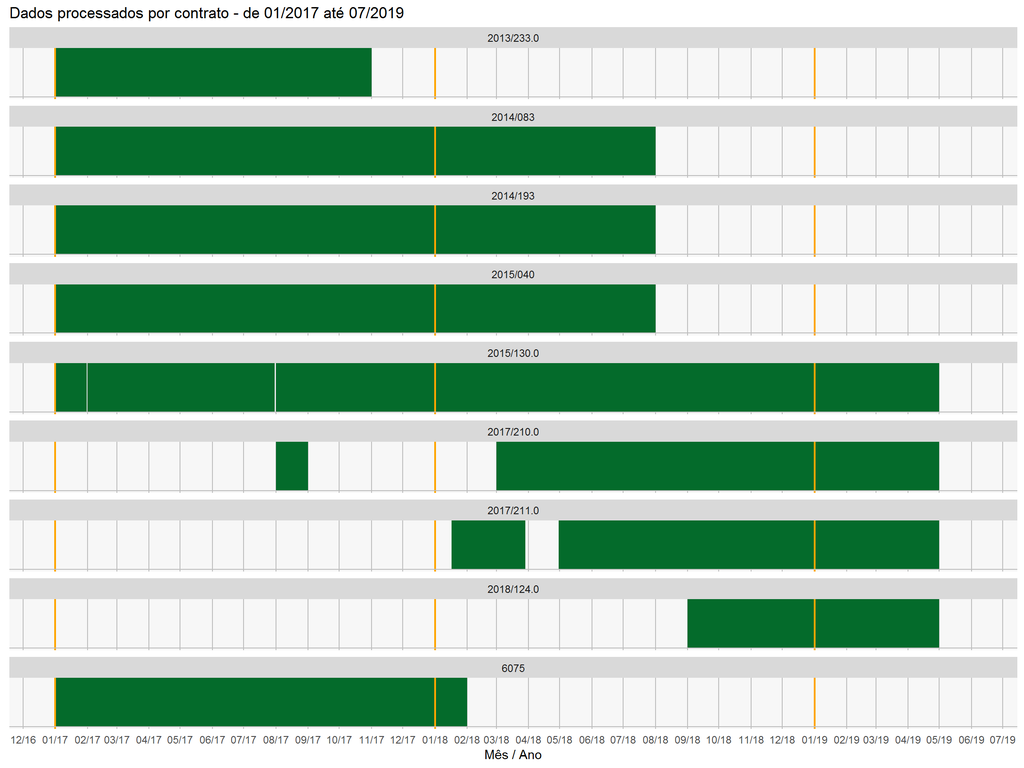

## Total acumulado de impressões

A visualização que melhor representou a evolução dos resultados foi o gráfico de linha, utilizando os intervalos temporais no eixo X e os valores obtidos no eixo Y. As representações abaixo foram calculadas utilizando valores acumulados.

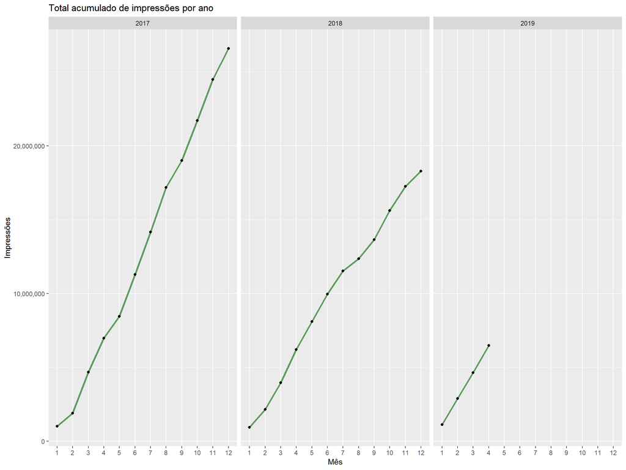

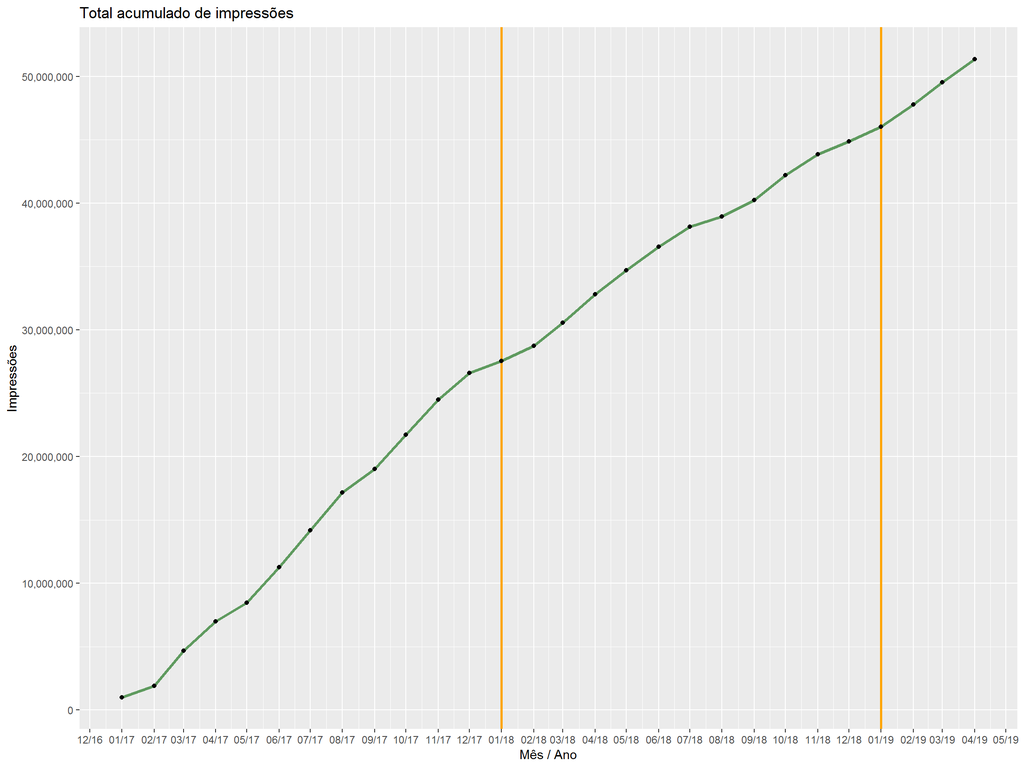

# 5. Apresentação do painel

A partir dos *insights* obtidos no item anterior, decidimos apresentar os resultados de maneira semelhante no painel, utilizamos gráficos mistos, de linhas e barras:

- Os resultados serão representados em forma de barra. A barra representou melhor a ideia de um resultado concreto que alcançamos em cada período.
- As metas serão representadas em forma de linha. A linha representou a intenção de cada indicador (aumentar ou diminuir o resultado)

Segue abaixo um Iframe carregando uma prévia deste painel ([também acessível por este link](https://inteligenciadenegocios5.camara.leg.br/extensions/TI_Verde/TI_Verde.html)):

[interactive chart not shown]

# 6. Próximas etapas

Baseado na minha contribuição para este projeto, descrevo abaixo quais etapas eu recomendo que sejam executadas para manutenção e aprimoramento deste projeto:

## Automação do *pipeline*

Automatizar os processos envolvidos é fundamental para garantir a consistência e funcionamento deste projeto nos anos subsequentes. Para isso, as seguintes atividades precisam ser desenvolvidas:

### 1. Padronização dos inputs

Cada input é fornecido de maneira diferente, conforme mencionado no primeiro item dos desafios encontrados. Enquanto não houver uma padronização dos dados fornecidos, será necessária uma análise manual de cada conteúdo processado sempre que um novo conjunto de dados for entregue.

### 2. Criação de um Banco de Dados (DB) relacional

Todos os dados processados neste projeto possuem algum relacionamento. Atualmente, todos os dados processados estão sendo exportados para .csv e consultados localmente sob demanda. Com essas informações disponíveis em um DB, este projeto poderá ser integrado facilmente em outras aplicações da Câmara, ou até mesmo ser continuado em outra linguagem de programação.

### 3. ETL e cálculos de indicadores e economias automatizados

Por fim, havendo uma padronização dos inputs e um DB com *schemas* modelados, scripts de automação podem ser elaborados para realizar ETL em novos dados e calcular os valores de cada indicador apresentado no painel.

## Evolução do painel

O painel pode ser expandido de diversas formas. Algumas atividades já podem ser executadas antes da automação do *pipeline*, tais como:

- Integrar o painel com Qlik Sense Enterprise ou NodeJS
- Disponibilizar mais interatividade para o usuário:
  - Permitir *drill-down* nos dados apresentados, como por exemplo:
    - Páginas impressas por diretoria e departamento;
    - Impressoras por diretoria e departamento;
    - Quantidade de pessoas em cada lotação.
  - Permitir comparações de economia entre anos específicos, não apenas com o ano anterior

# 7. Referências

- [Painel de sustentabilidade - TI Verde](https://inteligenciadenegocios5.camara.leg.br/extensions/TI_Verde/TI_Verde.html) e ferramentas:
  - [Bootstrap](https://getbootstrap.com/)
  - [ChartJS](https://www.chartjs.org/)
  - [Jquery](https://jquery.com/)
  - [FontAwesome](https://fontawesome.com/)
- Repositório no Git Câmara (intranet)
- Dados para input (DFS)
- [R-Cran](https://cran.r-project.org/)
- [RStudio](https://www.rstudio.com/)